# LTee Hypoxia Model — Gate B Manuscript-Figure Review

**Reviewer action:** Review the five recommended figures in order, focusing on claim support, panel density, and legibility at the displayed manuscript dimensions. The supplementary diagnostic and all intermediate drafts follow.

Each figure is paired with its legend, feedback or prompt responses, caveats, and local source files. Recommended final drafts appear before alternatives; raw refined and initial galleries should be collapsed unless they are the primary review item.

## Feedback Coverage

addressed: 17partially_addressed: 0blocked: 0dropped: 0deferred: 1

| ID | Source | Directive | Status | Output Or Disposition | First Report Section |
| --- | --- | --- | --- | --- | --- |
| `FD01` | feedback_manager_context.md; feedback_intake.md | Add chromosome trajectories to the matched-design figure. | addressed | final_figures/recommended/figure1.png | Figure 1 |
| `FD02` | feedback_manager_context.md; feedback_intake.md | Retain one integrated model overview. | addressed | final_figures/recommended/figure2.png | Figure 2 |
| `FD03` | feedback_manager_context.md; feedback_intake.md | Limit Figure 3A to growth rate over lineage passage. | addressed | final_figures/recommended/figure3.png | Figure 3 |
| `FD04` | feedback_manager_context.md; feedback_intake.md | Retain the historical control-versus-deprived comparison. | addressed | final_figures/recommended/figure3.png | Figure 3 |
| `FD05` | feedback_manager_context.md; feedback_intake.md | Do not draft Figure 3E or run a restricted-model comparison. | addressed | not_drafted.md; no Figure 3E artifact | Scope Boundaries |
| `FD06` | feedback_manager_context.md; feedback_intake.md | Lead Figures 3–5 with direct fit-quality evidence. | addressed | final_figures/recommended/figure3.png; final_figures/recommended/figure4.png; final_figures/recommended/figure5_joint_fit_adequacy_and_context_functions.png | Figures 3–5 |
| `FD07` | feedback_manager_context.md; feedback_intake.md | Treat historical Figure 4A–E as in-vivo analyses. | addressed | final_figures/recommended/figure4.png; subagent_notes/figure4.md | Figure 4 |
| `FD08` | feedback_manager_context.md; feedback_intake.md | Keep the fixed-O2 triptych and solution landscape in the main figure. | addressed | final_figures/recommended/figure4.png | Figure 4 |
| `FD09` | feedback_manager_context.md; feedback_intake.md | Use exact low/high-O2 parameter definitions and noncausal AUC language. | addressed | final_figures/recommended/figure4.png; subagent_notes/figure4_legend.md | Figure 4 |
| `FD10` | feedback_manager_context.md; feedback_intake.md | Use the six July joint-pair winners throughout Figure 5. | addressed | final_figures/recommended/figure5_joint_fit_adequacy_and_context_functions.png | Figure 5 |
| `FD11` | feedback_manager_context.md; feedback_intake.md | Order Figure 5 as fit quality, ratios, proliferation, missegregation, survival. | addressed | final_figures/recommended/figure5_joint_fit_adequacy_and_context_functions.png | Figure 5 |
| `FD12` | feedback_manager_context.md; feedback_intake.md | Retain a full all-six parameter-ratio view. | addressed | final_figures/recommended/figure5_joint_fit_adequacy_and_context_functions.png | Figure 5 |
| `FD13` | feedback_manager_context.md; feedback_intake.md | Leave Figure 6 out. | addressed | not_drafted.md; no Figure 6 artifact | Scope Boundaries |
| `FD14` | feedback_manager_context.md; feedback_intake.md | Defer journal-specific constraints until polishing. | deferred | not_drafted.md; repository style contract applied | Scope Boundaries |
| `FD15` | feedback_manager_context.md; feedback_intake.md | Retain vi_C01, vi_C02, and vi_C03. | addressed | final_figures/recommended/figure4.png | Figure 4 |
| `FD16` | feedback_manager_context.md; feedback_intake.md | Preserve the pooled in-vivo/in-vitro embedding and saved geometry. | addressed | final_figures/recommended/figure4.png; initial_subpanels/F4D/figure4D_pooled_embedding_preserved_source.png | Figure 4 |
| `FD17` | feedback_manager_context.md; feedback_intake.md | Keep main fit blocks compact; place optimizer diagnostics supplementary. | addressed | final_figures/recommended/figure3.png; final_figures/recommended/figure4.png; final_figures/recommended/figure5_joint_fit_adequacy_and_context_functions.png; supplementary/fit_quality_optimizer_diagno… | Fit Diagnostics |
| `FD18` | feedback_manager_context.md; feedback_intake.md | Draft only within the approved five-figure/exclusion boundary. | addressed | final_figures/recommended/; not_drafted.md | Scope Boundaries |

## Prior-Code Fidelity

Inherited panels must start from copied prior reviewed code, with local active scripts and diffs visible here.

| Panel | Class | Prior PNG | Prior Code | Copied Baseline | Active Local Script | Diff | Allowed Directives | Status | Blocker |
| --- | --- | --- | --- | --- | --- | --- | --- | --- | --- |
| `F1A` | inherited_targeted_fix | agent-dev/manuscript_work_packages/ltee_hypoxia_model/ideation/existing_context/assembled_fig1.png | oxygen/code/O2_supply_demand_MAP/analysis/plot_optimization_data_streams.R | agent-dev/manuscript_work_packages/ltee_hypoxia_model/drafting/prior_code/F1A/plot_optimization_data_streams.R | agent-dev/manuscript_work_packages/ltee_hypoxia_model/drafting/scripts/make_figure1.R | agent-dev/manuscript_work_packages/ltee_hypoxia_model/drafting/code_diffs/F1A.diff | FD01 | verified_targeted_adaptation | NA |
| `F1B` | novel_no_prior |  |  |  | agent-dev/manuscript_work_packages/ltee_hypoxia_model/drafting/scripts/make_figure1.R |  | FD01 | verified_novel | NA |
| `F1C` | novel_no_prior |  |  |  | agent-dev/manuscript_work_packages/ltee_hypoxia_model/drafting/scripts/make_figure1.R |  | FD01 | verified_novel | NA |
| `F2` | novel_no_prior |  |  |  | agent-dev/manuscript_work_packages/ltee_hypoxia_model/drafting/scripts/make_figure2.R |  | FD02 | verified_novel | NA |
| `F3A` | inherited_targeted_fix | agent-dev/manuscript_work_packages/ltee_hypoxia_model/ideation/existing_context/assembled_fig3.png#A | oxygen/code/O2_supply_demand_MAP/vis/viz_invitro_model_O2_supply_demand_MAP_results.R | agent-dev/manuscript_work_packages/ltee_hypoxia_model/drafting/prior_code/F3A/viz_invitro_model_O2_supply_demand_MAP_results.R | agent-dev/manuscript_work_packages/ltee_hypoxia_model/drafting/scripts/make_figure3.R | agent-dev/manuscript_work_packages/ltee_hypoxia_model/drafting/code_diffs/F3A.diff | FD03;FD04;FD06 | verified_targeted_adaptation | NA |
| `F3B` | inherited_targeted_fix | agent-dev/manuscript_work_packages/ltee_hypoxia_model/ideation/existing_context/assembled_fig3.png#B | oxygen/code/O2_supply_demand_MAP/vis/viz_invitro_model_O2_supply_demand_MAP_results.R | agent-dev/manuscript_work_packages/ltee_hypoxia_model/drafting/prior_code/F3B/viz_invitro_model_O2_supply_demand_MAP_results.R | agent-dev/manuscript_work_packages/ltee_hypoxia_model/drafting/scripts/make_figure3.R | agent-dev/manuscript_work_packages/ltee_hypoxia_model/drafting/code_diffs/F3B.diff | FD04 | verified_targeted_adaptation | NA |
| `F3C` | inherited_targeted_fix | agent-dev/manuscript_work_packages/ltee_hypoxia_model/ideation/existing_context/assembled_fig3.png#C | oxygen/code/O2_supply_demand_MAP/vis/viz_invitro_model_O2_supply_demand_MAP_results.R | agent-dev/manuscript_work_packages/ltee_hypoxia_model/drafting/prior_code/F3C/viz_invitro_model_O2_supply_demand_MAP_results.R | agent-dev/manuscript_work_packages/ltee_hypoxia_model/drafting/scripts/make_figure3.R | agent-dev/manuscript_work_packages/ltee_hypoxia_model/drafting/code_diffs/F3C.diff | FD18 | verified_targeted_adaptation | NA |
| `F3D` | inherited_targeted_fix | agent-dev/manuscript_work_packages/ltee_hypoxia_model/ideation/existing_context/assembled_fig3.png#D | oxygen/code/O2_supply_demand_MAP/vis/viz_invitro_model_O2_supply_demand_MAP_results.R | agent-dev/manuscript_work_packages/ltee_hypoxia_model/drafting/prior_code/F3D/viz_invitro_model_O2_supply_demand_MAP_results.R | agent-dev/manuscript_work_packages/ltee_hypoxia_model/drafting/scripts/make_figure3.R | agent-dev/manuscript_work_packages/ltee_hypoxia_model/drafting/code_diffs/F3D.diff | FD05;FD18 | verified_targeted_adaptation | NA |
| `F4A` | novel_no_prior |  |  |  | agent-dev/manuscript_work_packages/ltee_hypoxia_model/drafting/scripts/make_figure4.R |  | FD06 | verified_novel | NA |
| `F4B` | inherited_move | agent-dev/manuscript_work_packages/ltee_hypoxia_model/ideation/existing_context/assembled_fig4.png#A | oxygen/code/O2_supply_demand_MAP/vis/viz_invivo_model_O2_supply_demand_MAP_results.R | agent-dev/manuscript_work_packages/ltee_hypoxia_model/drafting/prior_code/F4B/viz_invivo_model_O2_supply_demand_MAP_results.R | agent-dev/manuscript_work_packages/ltee_hypoxia_model/drafting/scripts/make_figure4.R | agent-dev/manuscript_work_packages/ltee_hypoxia_model/drafting/code_diffs/F4B.diff | FD06;FD07 | verified_reordered_adaptation | NA |
| `F4C` | inherited_targeted_fix | agent-dev/manuscript_work_packages/ltee_hypoxia_model/ideation/existing_context/assembled_fig4.png#B-D | oxygen/code/O2_supply_demand_MAP/analysis/best_fit_parameter_feature/02_parameter_landscape_clustering/mode_parameter_contribution_analysis.R | agent-dev/manuscript_work_packages/ltee_hypoxia_model/drafting/prior_code/F4C/mode_parameter_contribution_analysis.R | agent-dev/manuscript_work_packages/ltee_hypoxia_model/drafting/scripts/make_figure4.R | agent-dev/manuscript_work_packages/ltee_hypoxia_model/drafting/code_diffs/F4C.diff | FD08;FD09 | verified_targeted_adaptation | NA |
| `F4D` | inherited_preserve | agent-dev/manuscript_work_packages/ltee_hypoxia_model/ideation/existing_context/assembled_fig4.png#F | oxygen/code/O2_supply_demand_MAP/analysis/best_fit_parameter_feature/04_combine_parameter_landscape/plot_pooled_embedding_curve_class.R | agent-dev/manuscript_work_packages/ltee_hypoxia_model/drafting/prior_code/F4D/plot_pooled_embedding_curve_class.R | agent-dev/manuscript_work_packages/ltee_hypoxia_model/drafting/scripts/make_figure4.R | agent-dev/manuscript_work_packages/ltee_hypoxia_model/drafting/code_diffs/F4D.diff | FD15;FD16 | verified_preserved_source | NA |
| `F4E` | inherited_targeted_fix | agent-dev/manuscript_work_packages/ltee_hypoxia_model/ideation/existing_context/assembled_fig4.png#E | oxygen/code/O2_supply_demand_MAP/analysis/best_fit_parameter_feature/02_parameter_landscape_clustering/clustering_report.R | agent-dev/manuscript_work_packages/ltee_hypoxia_model/drafting/prior_code/F4E/clustering_report.R | agent-dev/manuscript_work_packages/ltee_hypoxia_model/drafting/scripts/make_figure4.R | agent-dev/manuscript_work_packages/ltee_hypoxia_model/drafting/code_diffs/F4E.diff | FD15 | verified_targeted_adaptation | NA |
| `F5A` | novel_no_prior |  |  |  | agent-dev/manuscript_work_packages/ltee_hypoxia_model/drafting/scripts/make_figure5.R |  | FD06;FD10 | verified_novel | NA |
| `F5B` | inherited_replace | agent-dev/manuscript_work_packages/ltee_hypoxia_model/ideation/existing_context/assembled_fig5.png#E | oxygen/code/O2_supply_demand_MAP/util/o2_supply_demand_map_joint_parameter_plot.R | agent-dev/manuscript_work_packages/ltee_hypoxia_model/drafting/prior_code/F5B/o2_supply_demand_map_joint_parameter_plot.R | agent-dev/manuscript_work_packages/ltee_hypoxia_model/drafting/scripts/make_figure5.R | agent-dev/manuscript_work_packages/ltee_hypoxia_model/drafting/code_diffs/F5B.diff | FD10;FD11;FD12 | verified_directive_authorized_replacement | NA |
| `F5C` | inherited_replace | agent-dev/manuscript_work_packages/ltee_hypoxia_model/ideation/existing_context/assembled_fig5.png#B | oxygen/code/O2_supply_demand_MAP/util/o2_supply_demand_map_joint_parameter_plot.R | agent-dev/manuscript_work_packages/ltee_hypoxia_model/drafting/prior_code/F5C/o2_supply_demand_map_joint_parameter_plot.R | agent-dev/manuscript_work_packages/ltee_hypoxia_model/drafting/scripts/make_figure5.R | agent-dev/manuscript_work_packages/ltee_hypoxia_model/drafting/code_diffs/F5C.diff | FD10;FD11 | verified_directive_authorized_replacement | NA |
| `F5D` | inherited_replace | agent-dev/manuscript_work_packages/ltee_hypoxia_model/ideation/existing_context/assembled_fig5.png#C | oxygen/code/O2_supply_demand_MAP/util/o2_supply_demand_map_joint_parameter_plot.R | agent-dev/manuscript_work_packages/ltee_hypoxia_model/drafting/prior_code/F5D/o2_supply_demand_map_joint_parameter_plot.R | agent-dev/manuscript_work_packages/ltee_hypoxia_model/drafting/scripts/make_figure5.R | agent-dev/manuscript_work_packages/ltee_hypoxia_model/drafting/code_diffs/F5D.diff | FD10;FD11 | verified_directive_authorized_replacement | NA |
| `F5E` | inherited_replace | agent-dev/manuscript_work_packages/ltee_hypoxia_model/ideation/existing_context/assembled_fig5.png#D | oxygen/code/O2_supply_demand_MAP/util/o2_supply_demand_map_joint_parameter_plot.R | agent-dev/manuscript_work_packages/ltee_hypoxia_model/drafting/prior_code/F5E/o2_supply_demand_map_joint_parameter_plot.R | agent-dev/manuscript_work_packages/ltee_hypoxia_model/drafting/scripts/make_figure5.R | agent-dev/manuscript_work_packages/ltee_hypoxia_model/drafting/code_diffs/F5E.diff | FD10;FD11 | verified_directive_authorized_replacement | NA |

## Figure 1 — Matched design and chromosome trajectories

recommended

**Show full-resolution image**

**Additional Draft Outputs**

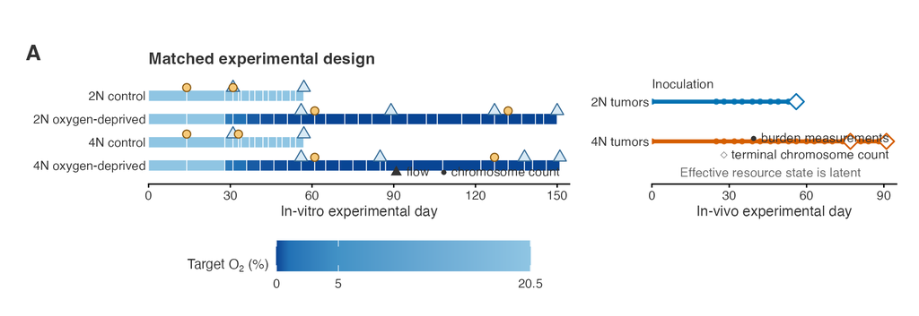

initial_subpanels/F1A/matched_design.png

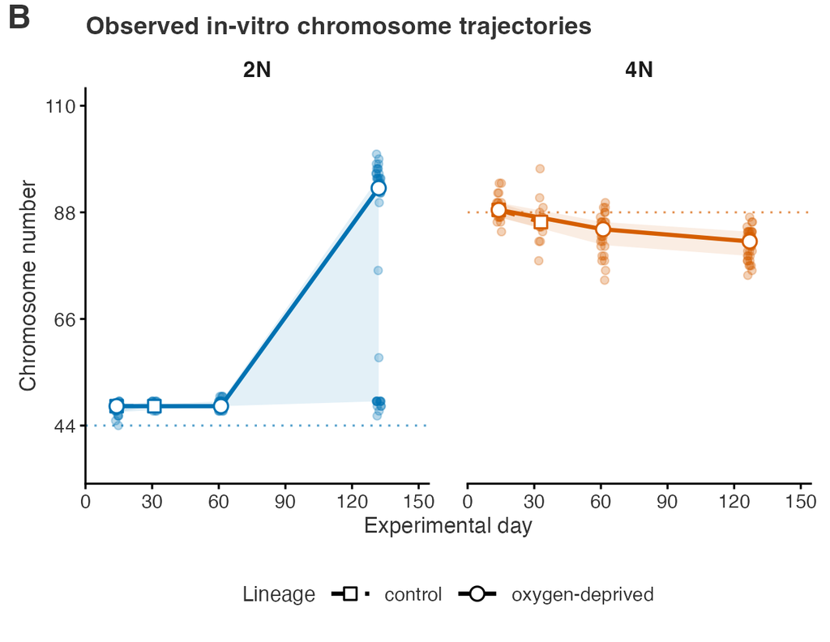

initial_subpanels/F1B/invitro_chromosome_trajectories.png

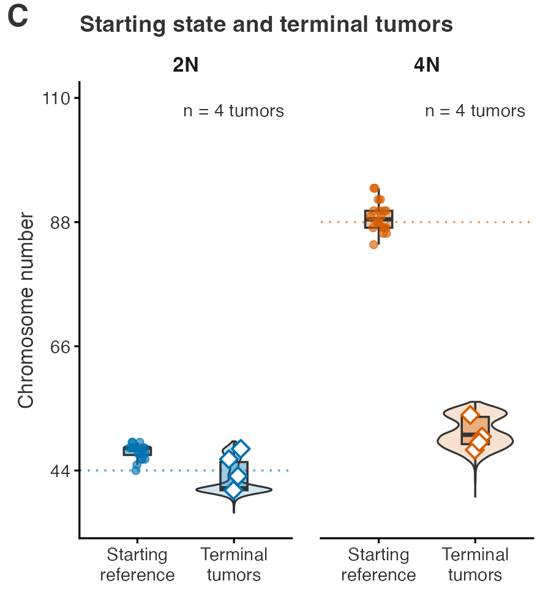

initial_subpanels/F1C/invivo_start_terminal_distributions.png

The study design is paired directly with the chromosome observations that motivate the modelling claims.

### Feedback Status

- `FD01` addressed Add chromosome trajectories to the matched-design figure.

### Legend And Panel Guide

**Figure 1. Matched experimental systems and motivating chromosome-number changes.** **(A)** Simplified design for matched SUM159 near-diploid (2N) and near-tetraploid (4N) lineages. Culture strips show the longest tracked control and oxygen-deprived paths, with known target O2 encoded from light to dark; triangles mark flow cytometry and circles mark chromosome counts. Tumor strips show burden-measurement times and terminal chromosome sampling. Tumor resource state was not measured and is latent in the model. **(B)** Observed cell-level chromosome numbers in culture. Lines and ribbons show medians and interquartile ranges; the shared starting reference begins both summary trajectories. Control series end earlier than oxygen-deprived series. **(C)** Starting cell-line reference karyotypes and terminal tumor-cell chromosome distributions. Boxes show distribution summaries, violins show terminal cell distributions, and diamonds show individual tumor medians (four tumors per starting-ploidy cohort). Starting and terminal measurements are distinct samples rather than longitudinal karyotyping of the same tumor.

### Feedback Or Prompt Items Addressed

- Adds the requested in-vitro chromosome trajectories.
- Shows the in-vivo starting reference and terminal tumor distributions.

### Caveats

- This is descriptive experimental context; no model fitting is shown.

### Review Files

- scripts/make_figure1.R
- subagent_notes/figure1.md
- source_tables/figure1_displayed_summaries.tsv

## Figure 2 — Integrated model overview

recommended

**Show full-resolution image**

**Additional Draft Outputs**

One schematic connects resource state, fitted growth and death, chromosome-state transitions, survival filtering, and context-specific observables.

### Feedback Status

- `FD02` addressed Retain one integrated model overview.

### Feedback Or Prompt Items Addressed

- Retains one integrated model overview rather than splitting the mechanism across figures.

### Caveats

- Arrows encode model structure and fitted links, not direct causal identification from the experiments.

### Review Files

- scripts/make_figure2.R
- subagent_notes/figure2.md

## Figure 3 — In-vitro fit adequacy and fitted functions

recommended

**Show full-resolution image**

**Additional Draft Outputs**

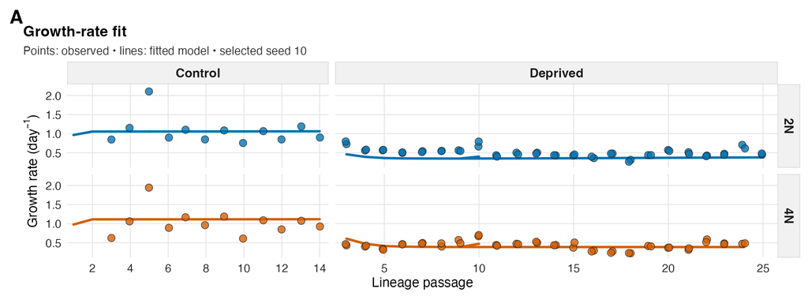

initial_subpanels/F3A/figure3A_initial.png

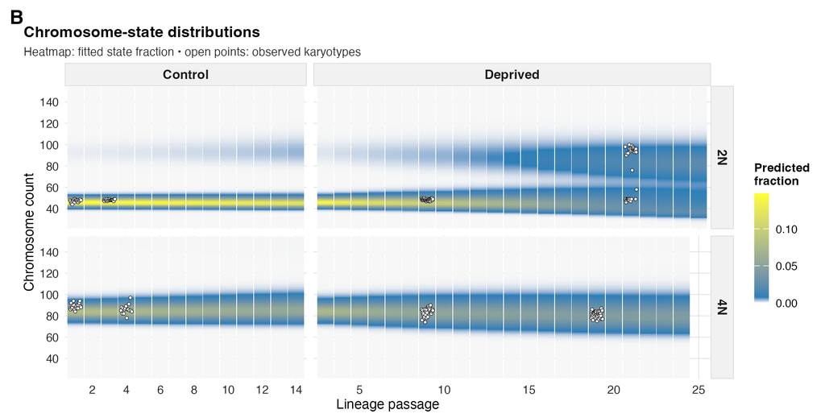

initial_subpanels/F3B/figure3B_initial.png

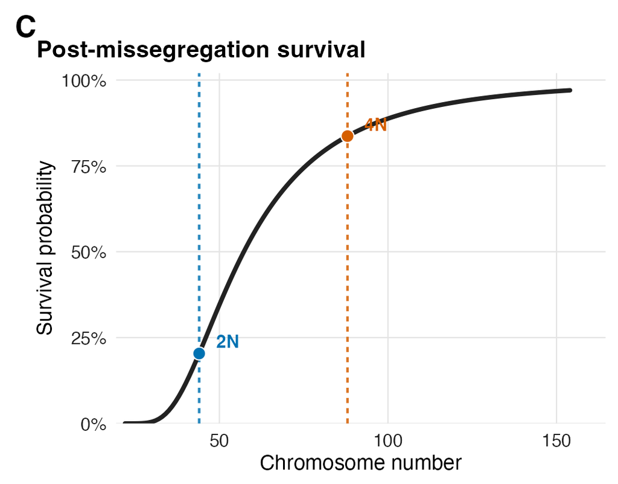

initial_subpanels/F3C/figure3C_initial.png

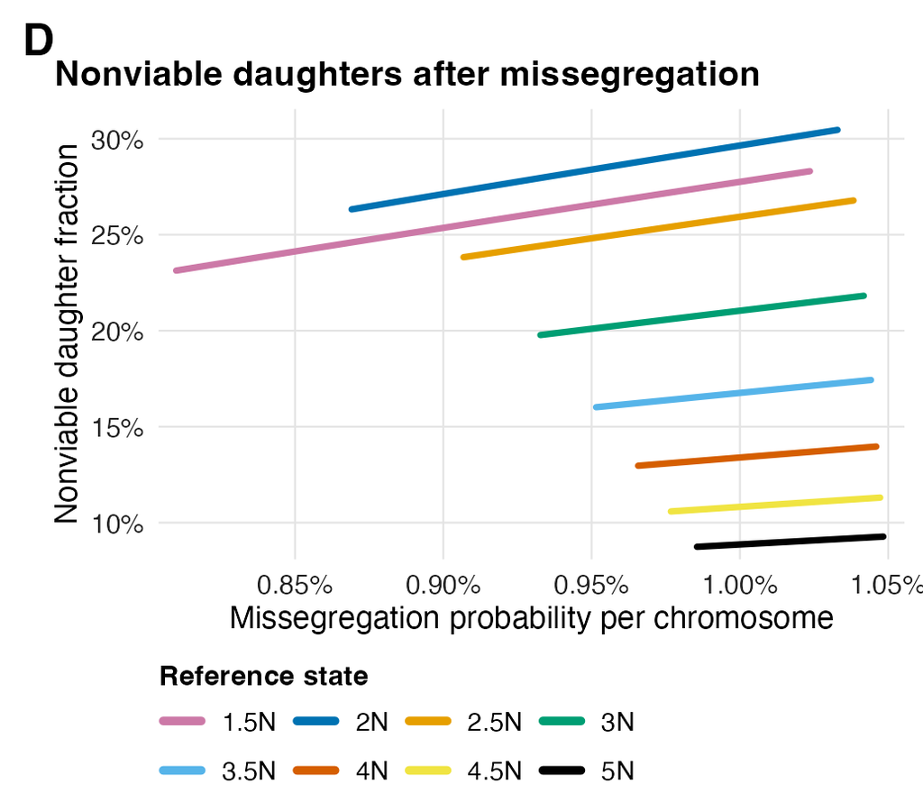

initial_subpanels/F3D/figure3D_initial.png

Direct growth-fit evidence leads the figure; controls remain visible before conditional fitted survival and nonviable-fraction summaries.

### Feedback Status

- `FD03` addressed Limit Figure 3A to growth rate over lineage passage.
- `FD04` addressed Retain the historical control-versus-deprived comparison.
- `FD05` addressed Do not draft Figure 3E or run a restricted-model comparison.
- `FD06` addressed Lead Figures 3–5 with direct fit-quality evidence.
- `FD17` addressed Keep main fit blocks compact; place optimizer diagnostics supplementary.
- `FD18` addressed Draft only within the approved five-figure/exclusion boundary.

### Legend And Panel Guide

**Figure 3. Direct fit quality and fitted chromosome-segregation functions.** **A,** Observed growth rates (points) and fitted growth rates from selected seed 10 (lineage-connected lines) across lineage passage, shown separately for control and oxygen-deprived 2N and 4N branches. **B,** Fitted chromosome-state fractions (heatmaps) with individual observed karyotypes (open points) overlaid at sampled lineage passages; all saved chromosome states and control branches are retained. **C,** Fitted post-missegregation survival as a function of chromosome number. Dashed lines and labeled points mark the 2N (`N = 44`) and 4N (`N = 88`) reference states. **D,** Model-implied nonviable-daughter fraction versus per-chromosome missegregation probability for 1.5N–5N reference states, using the saved oxygen-sweep curves. Controls were included in fitting and are not held-out validation data. Lineage passage denotes branch depth rather than calendar time. Panels C and D are fitted/model-implied quantities, and no parameter-uncertainty intervals are available.

### Feedback Or Prompt Items Addressed

- Panel A is restricted to growth over passage.
- The left-hand control conditions are retained.
- The rejected restricted-model panel is absent.

### Caveats

- Fit comparisons are in-sample summaries of saved outputs; they are not held-out validation.

### Review Files

- scripts/make_figure3.R
- subagent_notes/figure3.md

## Figure 4 — In-vivo fit adequacy and solution landscape

recommended

**Show full-resolution image**

**Additional Draft Outputs**

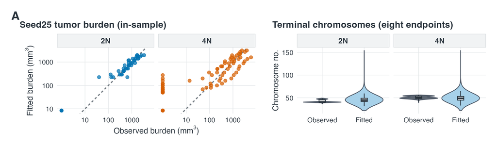

initial_subpanels/F4A/figure4A_fit_adequacy.png

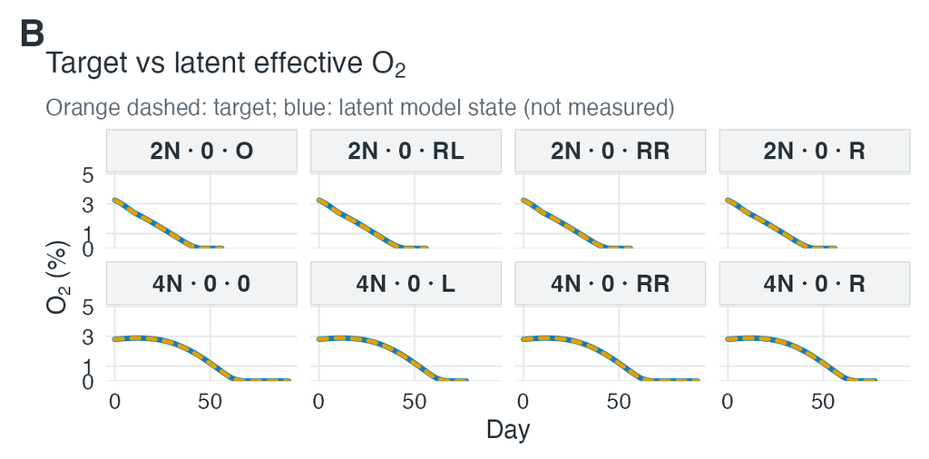

initial_subpanels/F4B/figure4B_latent_effective_o2.png

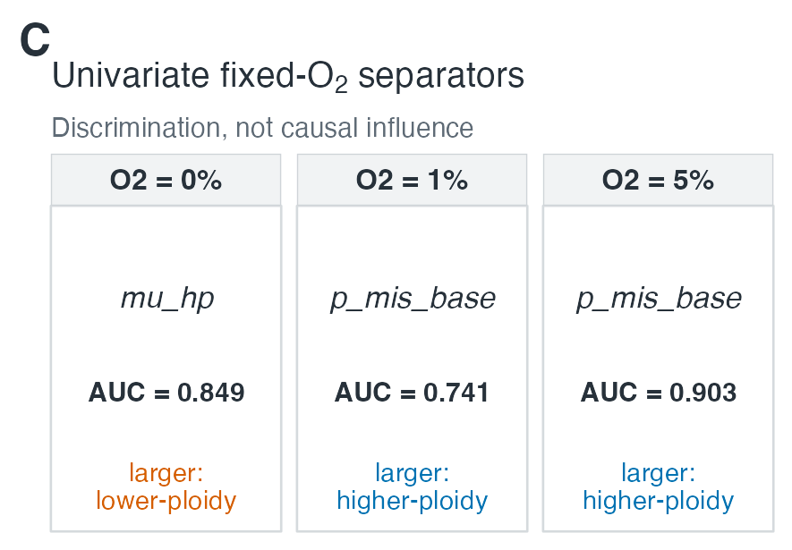

initial_subpanels/F4C/figure4C_univariate_separators.png

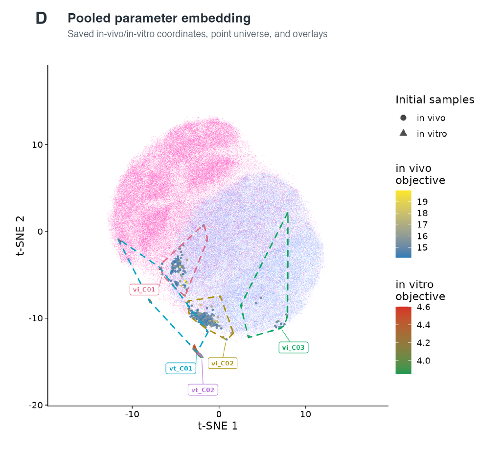

initial_subpanels/F4D/figure4D_pooled_embedding.png

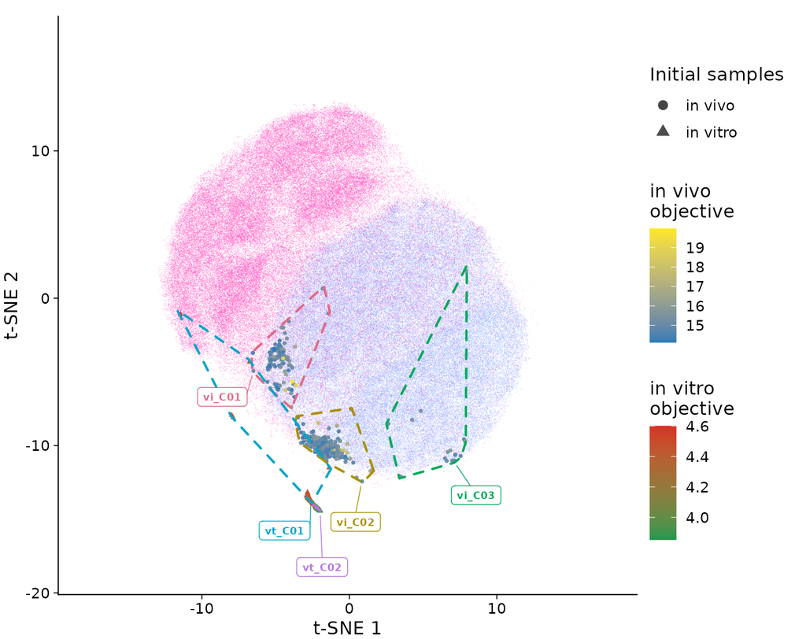

initial_subpanels/F4D/figure4D_pooled_embedding_layout_source.png

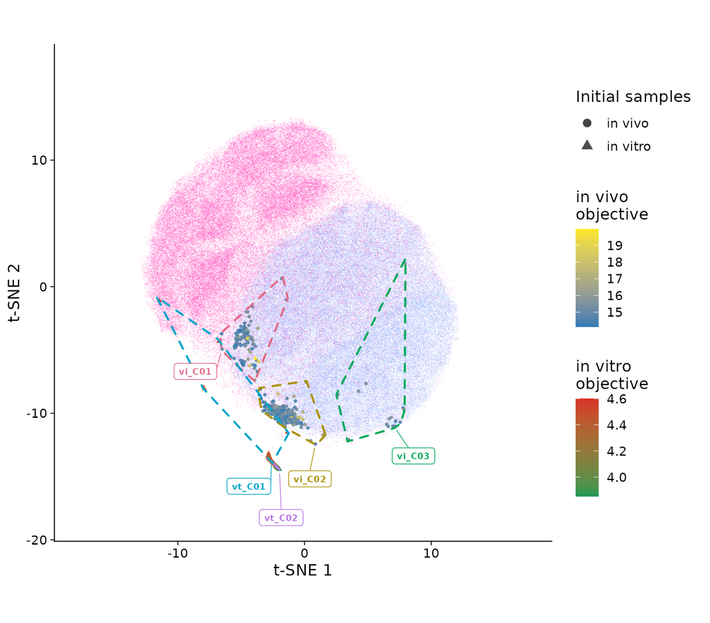

initial_subpanels/F4D/figure4D_pooled_embedding_preserved_source.png

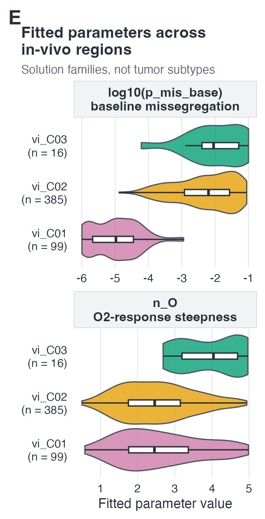

initial_subpanels/F4E/figure4E_region_parameters.png

Fit adequacy precedes latent oxygen, fixed-O2 separators, the unchanged pooled embedding, and parameter distributions for all three in-vivo regions.

### Feedback Status

- `FD06` addressed Lead Figures 3–5 with direct fit-quality evidence.
- `FD07` addressed Treat historical Figure 4A–E as in-vivo analyses.
- `FD08` addressed Keep the fixed-O2 triptych and solution landscape in the main figure.
- `FD09` addressed Use exact low/high-O2 parameter definitions and noncausal AUC language.
- `FD15` addressed Retain vi_C01, vi_C02, and vi_C03.
- `FD16` addressed Preserve the pooled in-vivo/in-vitro embedding and saved geometry.
- `FD17` addressed Keep main fit blocks compact; place optimizer diagnostics supplementary.

### Legend And Panel Guide

**Figure 4. In-vivo fit adequacy, latent oxygen dynamics, and the pooled fitted-solution landscape.** **A,** Observed versus fitted tumor burden for selected seed 25 (points; dashed line, identity) and weighted observed versus fitted terminal chromosome-number distributions across the eight in-vivo endpoints. Seed 25 is the lowest-total-objective weighted-MAP fit among 500 starts; these are in-sample comparisons. Necrosis is omitted because its exported predictions are unavailable. **B,** Prescribed oxygen target (orange dashed line, drawn above the blue trace) and latent model-implied effective oxygen (blue line) for the eight exposure schedules. Effective oxygen is a fitted state, not a tumor oxygen measurement. **C,** Strongest univariate separator of the two model-defined fixed-oxygen attractor modes at 0%, 1%, and 5% O2. At 0% O2, `mu_hp` is strongest (AUC = 0.849; larger in the lower-ploidy mode); at 1% and 5% O2, `p_mis_base` is strongest (AUC = 0.741 and 0.903, respectively; larger in the higher-ploidy mode). AUC quantifies discrimination, not causal influence. **D,** Preserved pooled in-vivo/in-vitro t-SNE point universe with the saved coordinates, initial-sample context, objective-value overlays, geometry, and labeled in-vivo (`vi_C01`–`vi_C03`) and in-vitro (`vt_C01`–`vt_C02`) solution regions. No embedding or model fit was recomputed. **E,** Distributions of fitted `log10(p_mis_base)` and `n_O` across the three formal in-vivo regions (`vi_C01`, n = 99; `vi_C02`, n = 385; `vi_C03`, n = 16); white boxes show medians and interquartile ranges. Regions denote fitted solution families rather than biological tumor subtypes, and proximity in the embedding is descriptive.

### Feedback Or Prompt Items Addressed

- The pooled in-vivo/in-vitro embedding and saved geometry are preserved.
- All vi_C01, vi_C02, and vi_C03 regions remain visible.
- AUCs are labelled as univariate separators, not causal effects.

### Caveats

- Effective O2 is a fitted latent state, not a tumor oxygen measurement.
- Necrosis is excluded because the prediction export remains unavailable.

### Review Files

- scripts/make_figure4.R
- subagent_notes/figure4.md

## Figure 5 — Joint-fit adequacy and context functions

recommended

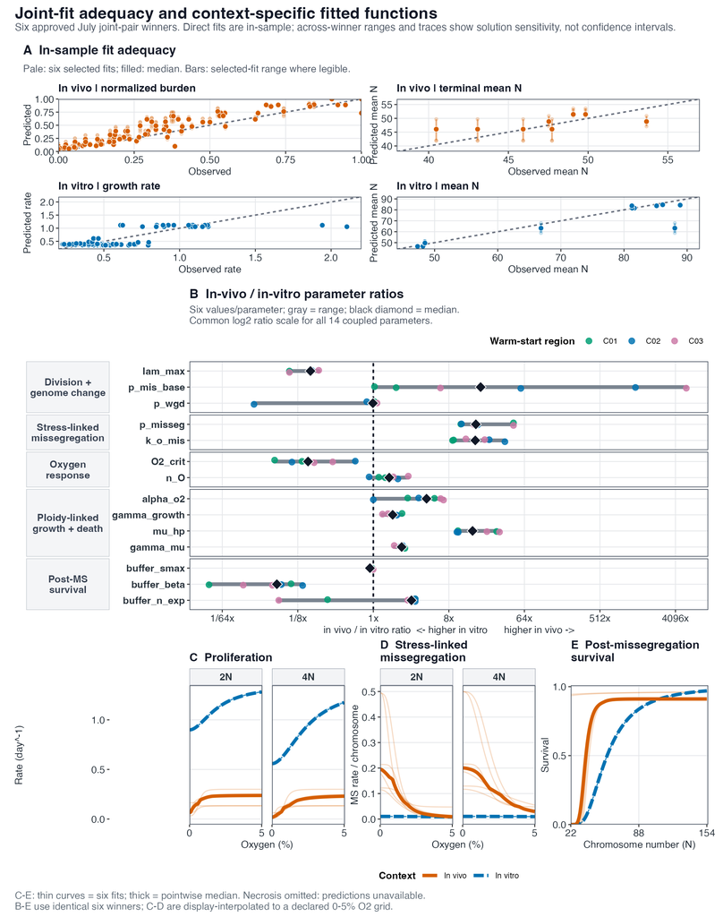

**Show full-resolution image**

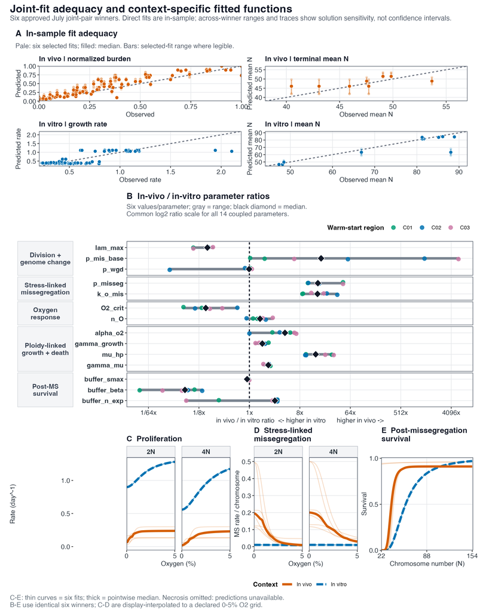

**Additional Draft Outputs**

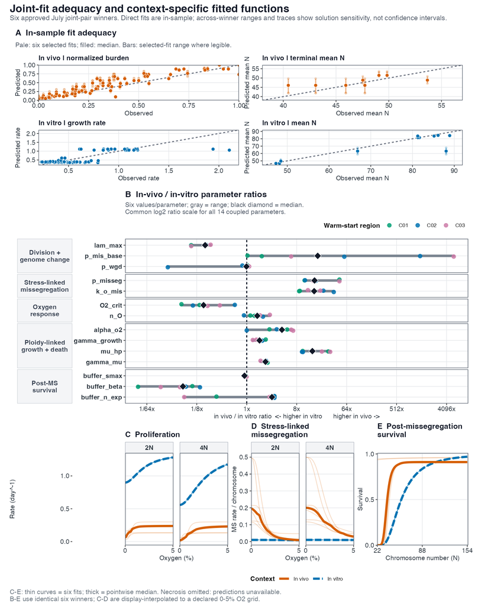

refined_subpanels/figure5_joint_fit_adequacy_and_context_functions.png

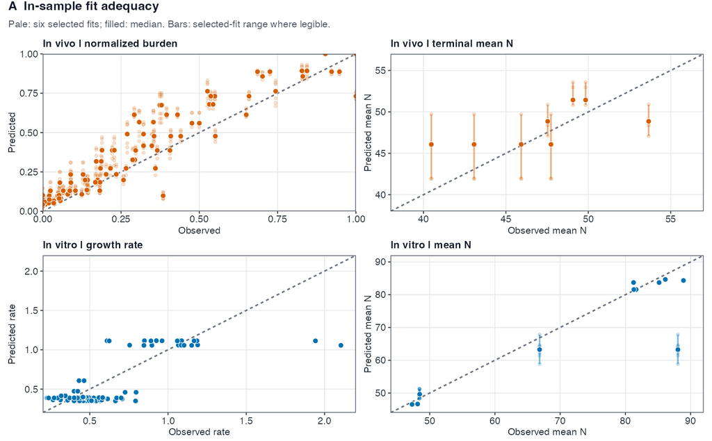

initial_subpanels/F5A/figure5A_fit_adequacy.png

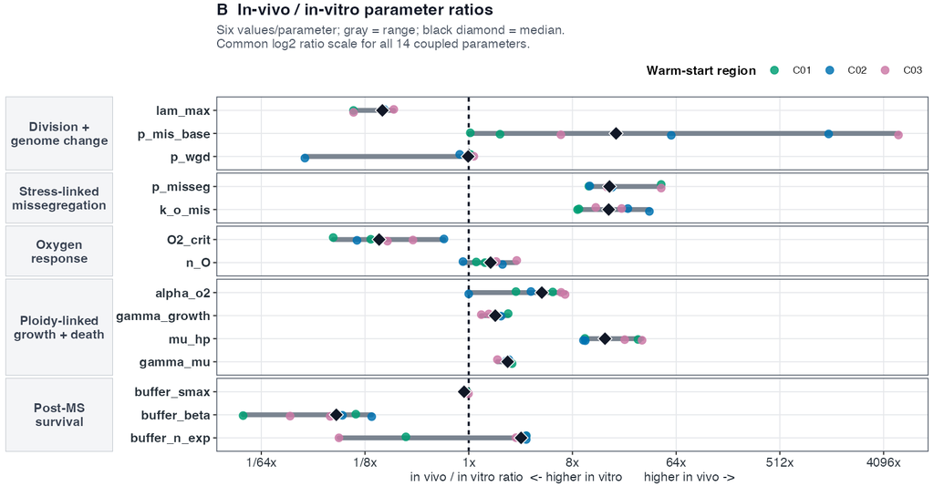

initial_subpanels/F5B/figure5B_parameter_ratios.png

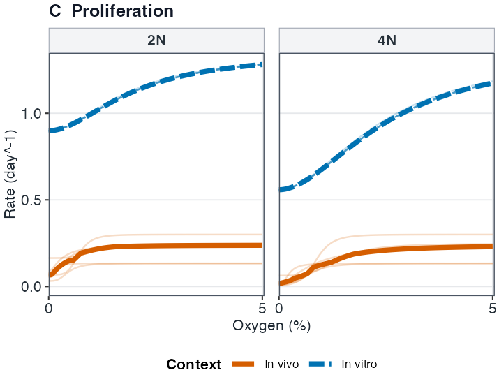

initial_subpanels/F5C/figure5C_proliferation.png

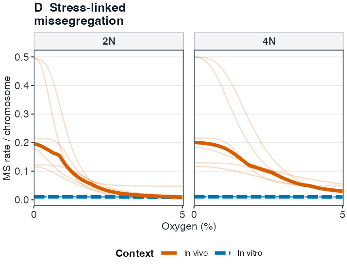

initial_subpanels/F5D/figure5D_missegregation.png

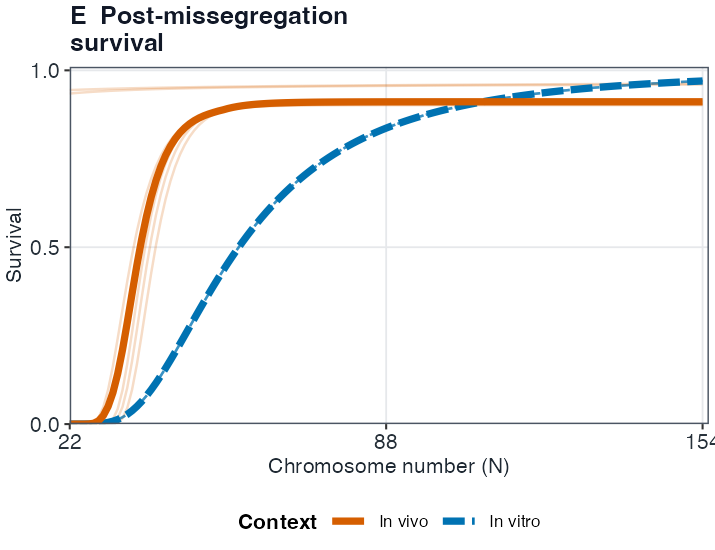

initial_subpanels/F5E/figure5E_survival.png

The common six-winner joint-fit universe is used consistently from direct fit checks through ratios and context-specific functions.

### Feedback Status

- `FD06` addressed Lead Figures 3–5 with direct fit-quality evidence.
- `FD10` addressed Use the six July joint-pair winners throughout Figure 5.
- `FD11` addressed Order Figure 5 as fit quality, ratios, proliferation, missegregation, survival.
- `FD12` addressed Retain a full all-six parameter-ratio view.
- `FD17` addressed Keep main fit blocks compact; place optimizer diagnostics supplementary.
- `FD18` addressed Draft only within the approved five-figure/exclusion boundary.

### Legend And Panel Guide

**Figure 5. Joint-fit adequacy and context-specific fitted functions.** **A,** Direct in-sample observed-versus-predicted comparisons for within-series normalized tumor burden, terminal mean chromosome number, passage growth rate, and mean karyotype. Pale points show predictions from all six approved July joint-pair winners; filled points show their median, and vertical bars show their range where legible. Dashed diagonals denote equality. **B,** In-vivo to in-vitro ratios for all 14 soft-coupled parameters on a common log2 scale. Colored points are the six winners (color denotes warm-start region), gray segments span their range, black diamonds mark their median, and the vertical dashed line marks a ratio of one. **C,** Fitted proliferation rate versus oxygen for 2N and 4N reference states. **D,** Fitted per-chromosome missegregation rate versus oxygen for the same states. **E,** Fitted survival after missegregation versus chromosome number. In C-E, orange solid curves are in vivo, blue dashed curves are in vitro, thin curves are the six selected solutions, and thick curves are pointwise medians. C-D use linear display interpolation on a common 0-5% oxygen grid. All fit comparisons are in-sample, and across-winner ranges and traces represent solution sensitivity rather than confidence intervals. Necrosis is omitted because predicted values are unavailable in the saved joint-fit exports.

### Feedback Or Prompt Items Addressed

- Fit quality is shown before biological interpretation.
- All parameter ratios and all six joint winners are retained.
- The approved proliferation, missegregation, and survival order is used.

### Caveats

- Displayed curves summarize saved fitted parameterizations; no optimizer refit was run.

### Review Files

- scripts/make_figure5.R
- subagent_notes/figure5.md

## Supplementary fit and optimizer diagnostics

supplementary

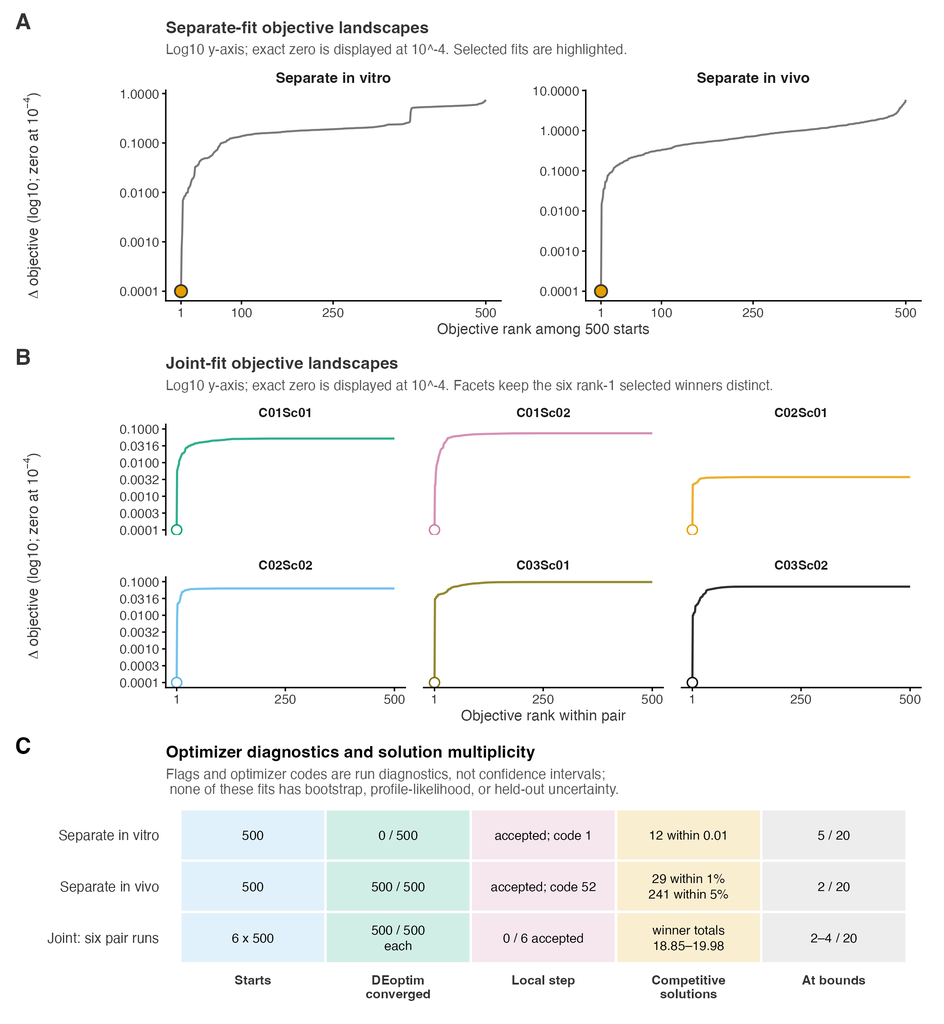

**Show full-resolution image**

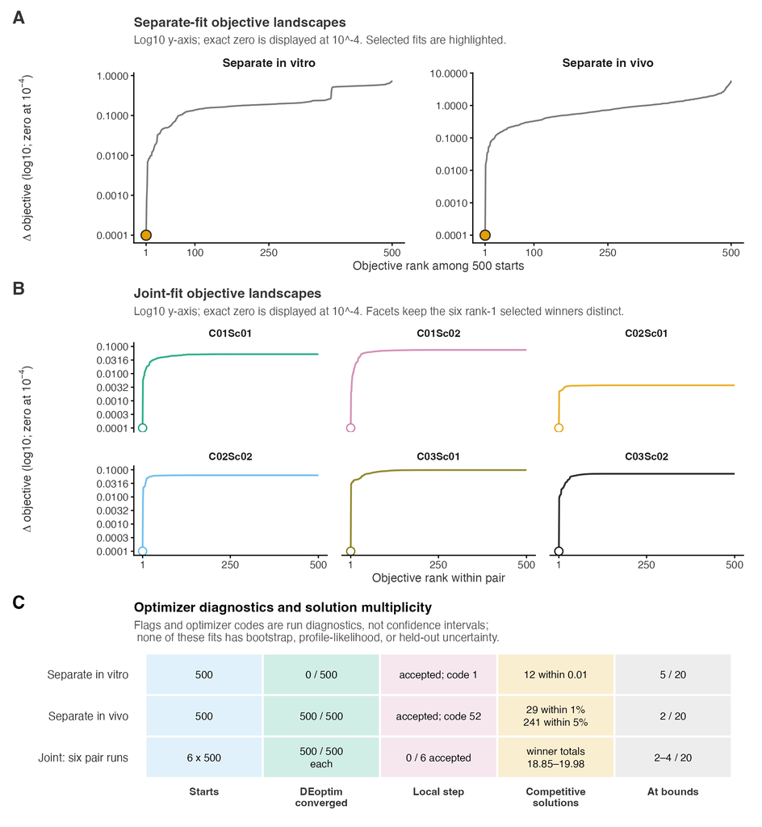

Saved objective distributions and optimizer-status diagnostics support the compact direct-fit blocks without crowding the main figures.

### Feedback Status

- `FD17` addressed Keep main fit blocks compact; place optimizer diagnostics supplementary.

### Legend And Panel Guide

**Supplementary figure. Optimizer-start distributions and solution multiplicity.** **(A)** Objective difference from the best result across 500 starts for the separate in-vitro and in-vivo fits; highlighted points are seed 10 and seed 25, respectively. **(B)** Objective difference within each of the six approved 500-start joint-pair runs; open points mark the selected winner of each run. All six are rank-1/zero-difference winners and are shown in separate warm-start-pair facets. In A and B, the y-axis is log10; exact zero differences are displayed at `1e-4`. **(C)** Stored run diagnostics, competitive-solution counts, and active-parameter boundary counts. These quantities describe optimization and solution sensitivity. They do not constitute held-out validation, posterior uncertainty, confidence intervals, or identifiability analysis.

### Feedback Or Prompt Items Addressed

- Implements the approved separation of compact main fit blocks and supplementary optimizer diagnostics.

### Caveats

- Diagnostics report saved optimization records as-is and do not constitute new optimization.

### Review Files

- scripts/make_fit_diagnostics.R
- supplementary/fit_quality_optimizer_diagnostics.tsv
- subagent_notes/fit_diagnostics.md

## Approved scope boundaries

scope

No primary image for this report card.

The package stops at the approved Gate B boundary.

### Feedback Status

- `FD05` addressed Do not draft Figure 3E or run a restricted-model comparison.
- `FD13` addressed Leave Figure 6 out.
- `FD14` deferred Defer journal-specific constraints until polishing.
- `FD18` addressed Draft only within the approved five-figure/exclusion boundary.

### Legend And Panel Guide

#### Not drafted in Gate B

- Figure 3E: rejected by FD05. No restricted-model refit or negative-control ablation will be run. - Figure 6 and its supplementary analytical grid: deferred by FD13 and FD18. - Necrosis predictions: excluded because the existing export is incomplete and FD18 does not authorize resolving it. - Production TeX edits and journal-specific polishing: outside the Gate B drafting scope. - Conservative and exploratory final variants: not generated because Gate A approved one explicit five-figure architecture and did not identify an unresolved visual decision requiring competing versions.

### Feedback Or Prompt Items Addressed

- No Figure 3E or restricted-model comparison was drafted.
- Figure 6 remains deferred.
- No optimizer refits or production manuscript edits were performed.

### Caveats

- Journal-specific polishing remains a later gate.

### Review Files

- not_drafted.md
- feedback_intake.md

**Appendix: full notes and feedback handoff context**

### feedback_manager_context.md

```
# Feedback-manager context

## Authorizing handoff

Drafting consumes the closed Gate A handoff at:

- `agent-dev/manuscript_work_packages/ltee_hypoxia_model/ideation/feedback_manager_context.md`
- `agent-dev/manuscript_work_packages/ltee_hypoxia_model/ideation/feedback_decisions.csv`
- `agent-dev/manuscript_work_packages/ltee_hypoxia_model/ideation/ideas.md`
- `agent-dev/manuscript_work_packages/ltee_hypoxia_model/ideation/ideation_report.html`

The canonical feedback-manager tracking roots are:

- `agent-dev/manuscript_work_packages/ltee_hypoxia_model/feedback_tracking/20260703_ltee_results_figure_review`
- `agent-dev/manuscript_work_packages/ltee_hypoxia_model/feedback_tracking/20260724_ideation_report_review`
- `agent-dev/manuscript_work_packages/ltee_hypoxia_model/feedback_tracking/20260724_figure4_umap_correction`
- `agent-dev/manuscript_work_packages/ltee_hypoxia_model/feedback_tracking/20260724_fig4_three_regions_confirmation`
- `agent-dev/manuscript_work_packages/ltee_hypoxia_model/feedback_tracking/20260724_gate_a_approval`

The relevant spans and durable work units were already served to and signed off
by `manuscript-figure-workflow` during Gate A. Drafting does not reinterpret or
replace those records; it implements their approved state. The user's current
`proceed` instruction authorizes execution but adds no new scientific
directive.

## Binding drafting state

- Draft Figures 1–5 only.
- Use compact direct observed–predicted evidence first in Figures 3–5.
- Keep objective distributions and optimizer diagnostics supplementary.
- Keep Figure 3 controls; remove Figure 3E.
- Keep the Figure 4 pooled in-vivo/in-vitro embedding unchanged, including all
  three displayed in-vivo solution regions: `vi_C01`, `vi_C02`, and `vi_C03`.
- Describe Figure 4 AUCs as univariate separators, not causal effects.
- Use the same six approved July joint-pair winners throughout Figure 5.
- Do not refit optimizers, edit the production TeX manuscript, resolve the
  necrosis export, revive Figure 6, or create a new analytical grid.

## Feedback return

Gate B artifacts and validation evidence are returned through the existing
feedback-manager tracking root at closeout. This file remains scope context;
it does not create a parallel closure ledger.
```

### feedback_intake.md

```
# Drafting feedback intake

## Inputs and scope

| input | role |
|---|---|
| `ltee_hypoxia_model.tex` | Restored manuscript and historical caption context; read-only in Gate B |
| `agent-dev/manuscript_work_packages/ltee_hypoxia_model/ideation/ideation_report.html` | Approved Gate A review surface |
| `agent-dev/manuscript_work_packages/ltee_hypoxia_model/ideation/ideas.md` | Approved five-figure drafting contract |
| `agent-dev/manuscript_work_packages/ltee_hypoxia_model/ideation/feedback_decisions.csv` | Stable directive ledger |
| `agent-dev/manuscript_work_packages/ltee_hypoxia_model/ideation/source_inventory.csv` | Source and generator inventory |
| `agent-dev/manuscript_work_packages/ltee_hypoxia_model/ideation/tex_figure_requirements.csv` | Panel roles and claim guardrails |
| `agent-dev/manuscript_work_packages/ltee_hypoxia_model/ideation/fit_quality_evidence.csv` | Fit-quality sources and limitations |
| `agent-dev/manuscript_work_packages/ltee_hypoxia_model/ideation/feedback_manager_context.md` | Canonical feedback-manager handoff |

Package decision: `draft` Figures 1–5. Figure 6 is
`defer_to_future_user_decision`. Production manuscript edits are
`defer_to_manuscript_assembly`.

## Directive coverage plan

| directive_id | drafting instruction | evidence/output | final status |
|---|---|---|---|
| FD01 | Add chromosome trajectories to the matched-design figure. | `final_figures/recommended/figure1.png` | addressed |
| FD02 | Retain one integrated model overview. | `final_figures/recommended/figure2.png` | addressed |
| FD03 | Limit Figure 3A to growth rate over lineage passage. | `final_figures/recommended/figure3.png` | addressed |
| FD04 | Retain the historical control-versus-deprived comparison. | `final_figures/recommended/figure3.png` | addressed |
| FD05 | Do not draft Figure 3E or run a restricted-model comparison. | `not_drafted.md`; no Figure 3E artifact | addressed |
| FD06 | Lead Figures 3–5 with direct fit-quality evidence. | Figures 3A, 4A, and 5A in `final_figures/recommended/` | addressed |
| FD07 | Treat historical Figure 4A–E as in-vivo analyses. | `subagent_notes/figure4.md`; `subagent_notes/figure4_legend.md` | addressed |
| FD08 | Keep the fixed-O2 triptych and solution landscape in the main figure. | `final_figures/recommended/figure4.png` | addressed |
| FD09 | Use exact low/high-O2 parameter definitions and noncausal AUC language. | Figure 4C labels and `subagent_notes/figure4_legend.md` | addressed |
| FD10 | Use the six July joint-pair winners throughout Figure 5. | `final_figures/recommended/figure5_joint_fit_adequacy_and_context_functions.png`; `source_manifest.csv` | addressed |
| FD11 | Order Figure 5 as fit quality, ratios, proliferation, missegregation, survival. | Figure 5A–E | addressed |
| FD12 | Retain a full all-six parameter-ratio view. | Figure 5B | addressed |
| FD13 | Leave Figure 6 out. | `not_drafted.md`; no Figure 6 artifact | addressed |
| FD14 | Defer journal-specific constraints until polishing. | `not_drafted.md`; repository style contract applied | deferred |
| FD15 | Retain `vi_C01`, `vi_C02`, and `vi_C03`. | Figure 4D–E | addressed |
| FD16 | Preserve the pooled in-vivo/in-vitro embedding and saved geometry. | Figure 4D; pinned raster recorded in `source_manifest.csv` | addressed |
| FD17 | Keep main fit blocks compact; place optimizer diagnostics supplementary. | Figures 3A, 4A, 5A; `supplementary/fit_quality_optimizer_diagnostics.png` | addressed |
| FD18 | Draft only within the approved five-figure/exclusion boundary. | Five recommended figures plus declared supplementary diagnostic | addressed |
```